# 04-Ensembling

```r
library(tidyverse)
library(tidymodels)
library(tune)

source(here::here("materials/exercises/04-helpers.R"))

fit_split <- function(formula, model, split, ...) {
  wf <- workflows::add_model(workflows::add_formula(workflows::workflow(), formula, blueprint = hardhat::default_formula_blueprint(indicators = "none")), model)
  tune::last_fit(wf, split, ...)
}

get_tree_fit <- function(results) {
  results %>%
    pluck(".workflow", 1) %>%
    workflows::pull_workflow_fit()
}

# read in the data
stackoverflow <- read_rds(here::here("materials/data/stackoverflow.rds"))

# split the data
set.seed(100) # Important!
so_split <- initial_split(stackoverflow, strata = remote)
so_train <- training(so_split)
so_test  <- testing(so_split)
```

# Your turn 1

Fill in the blanks to return the accuracy and ROC AUC for the vanilla decision tree model.

```r
vanilla_tree_spec <-
  decision_tree() %>%
  set_engine("rpart") %>%
  set_mode("classification")

set.seed(100) # Important!
fit_split(remote ~ .,
          model = vanilla_tree_spec,
          split = so_split) %>%
  collect_metrics()
```

```
## # A tibble: 2 x 3
##   .metric  .estimator .estimate
##   <chr>    <chr>          <dbl>
## 1 accuracy binary         0.682
## 2 roc_auc  binary         0.710
```

```r
args(vanilla_tree_spec)
```

# Your Turn 2

Create a new classification tree model spec; call it `big_tree_spec`. Set the cost complexity to `0`, and the minimum number of data points in a node to split to be `1`.

Compare the metrics of the big tree to the vanilla tree- which one predicts the test set better?

*Hint: you’ll need https://tidymodels.github.io/parsnip/reference/decision_tree.html*

```r
big_tree_spec <-
  decision_tree(cost_complexity = 0., min_n = 1) %>%
  set_engine("rpart") %>%
  set_mode("classification")

fit_split(remote ~ .,
          model = big_tree_spec,
          split = so_split) %>%
  collect_metrics()
```

```
## # A tibble: 2 x 3
##   .metric  .estimator .estimate
##   <chr>    <chr>          <dbl>
## 1 accuracy binary         0.629
## 2 roc_auc  binary         0.629
```

# Your Turn 3

Let’s combine bootstrapping with decision trees.

Do **Round 1** on your handouts.

# Your Turn 4

Now, let’s add the aggregating part.

Do **Round 2** on your handouts.

# Your Turn 5

Create a new model spec called `rf_spec`, which will learn an ensemble of classification trees from our training data using the **ranger** package.

Compare the metrics of the random forest to your two single tree models (vanilla and big)- which predicts the test set better?

*Hint: you’ll need https://tidymodels.github.io/parsnip/articles/articles/Models.html*

```r
set.seed(100) # Important!
rf_spec <-
  rand_forest(mode = "classification") %>%
  set_engine("ranger")

fit_split(remote ~ .,
          model = rf_spec,
          split = so_split) %>%
  collect_metrics()
```

```
## # A tibble: 2 x 3
##   .metric  .estimator .estimate
##   <chr>    <chr>          <dbl>
## 1 accuracy binary         0.717
## 2 roc_auc  binary         0.778
```

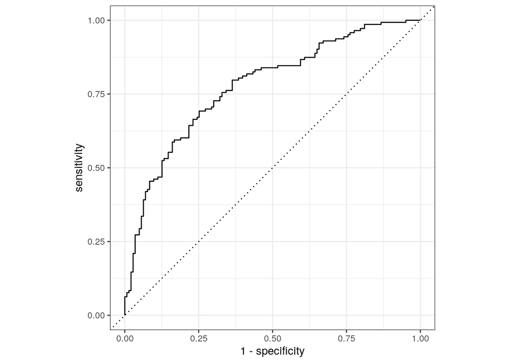

```r
fit_split(remote ~ .,
          model = rf_spec,
          split = so_split) %>%
  collect_predictions() %>%
  roc_curve(truth = remote, estimate = .pred_Remote) %>%
  autoplot()
```

# Your Turn 6

Challenge: Make 4 more random forest model specs, each using 4, 8, 12, and 20 variables at each split. Which value maximizes the area under the ROC curve?

*Hint: you’ll need https://tidymodels.github.io/parsnip/reference/rand_forest.html*

```r
mtry_vect <- c(4, 8, 12, 20)
metrics <- purrr::map(mtry_vect, function(mtry_val){
  rf_spec <-
    rand_forest(mtry = mtry_val) %>%
    set_engine("ranger") %>%
    set_mode("classification")

  set.seed(100)
  fit_split(remote ~ .,
            model = rf_spec,
            split = so_split) %>%
    collect_metrics() %>%
    mutate(cur_mtry = mtry_val)
})
metrics_all <- bind_rows(metrics)
metrics_all
```

```
## # A tibble: 8 x 4
##   .metric  .estimator .estimate cur_mtry
##   <chr>    <chr>          <dbl>    <dbl>
## 1 accuracy binary         0.717        4
## 2 roc_auc  binary         0.778        4
## 3 accuracy binary         0.703        8
## 4 roc_auc  binary         0.771        8
## 5 accuracy binary         0.710       12
## 6 roc_auc  binary         0.769       12
## 7 accuracy binary         0.713       20
## 8 roc_auc  binary         0.762       20
```

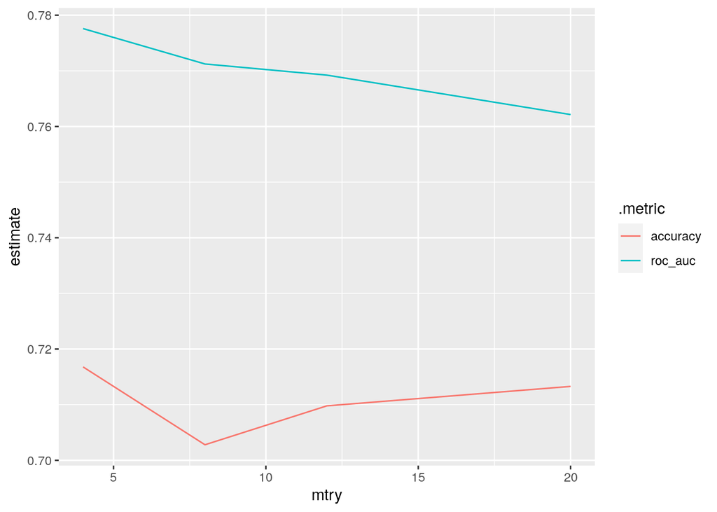

```r
ggplot(metrics_all, aes(cur_mtry, .estimate)) +
  geom_line(aes(group = .metric, color = .metric)) +
  xlab("mtry") + ylab("estimate")
```

# Bagging

```r
treebag_spec <-
  rand_forest(mtry = .preds()) %>%
  set_engine("ranger") %>%
  set_mode("classification")

set.seed(100)
fit_split(remote ~ .,
          model = treebag_spec,
          split = so_split) %>%
  collect_metrics()
```

```
## # A tibble: 2 x 3
##   .metric  .estimator .estimate
##   <chr>    <chr>          <dbl>
## 1 accuracy binary         0.713
## 2 roc_auc  binary         0.762
```

# Fitting based on importance of variables

```r
rf_imp_spec <-
  rand_forest(mtry = 4) %>%
  set_engine("ranger", importance = 'impurity') %>%
  set_mode("classification")

imp_fit <-
  fit_split(remote ~ .,
            model = rf_imp_spec,
            split = so_split)

imp_fit
```

```
## # Resampling results
## # Monte Carlo cross-validation (0.75/0.25) with 1 resamples
## # A tibble: 1 x 6
##   splits        id           .metrics      .notes      .predictions    .workflow
##   <list>        <chr>        <list>        <list>      <list>          <list>
## 1 <split [864/… train/test … <tibble [2 ×… <tibble [0… <tibble [286 ×… <workflo…
```

```r
source("04-helpers.R")
get_tree_fit(imp_fit)
```

```
## parsnip model object
##
## Fit time:  299ms
## Ranger result
##
## Call:
##  ranger::ranger(formula = ..y ~ ., data = data, mtry = ~4, importance = ~"impurity",      num.threads = 1, verbose = FALSE, seed = sample.int(10^5,          1), probability = TRUE)
##
## Type:                             Probability estimation
## Number of trees:                  500
## Sample size:                      864
## Number of independent variables:  20
## Mtry:                             4
## Target node size:                 10
## Variable importance mode:         impurity
## Splitrule:                        gini
## OOB prediction error (Brier s.):  0.2204233
```

A package to visualize importance of variables: https://koalaverse.github.io/vip/index.html

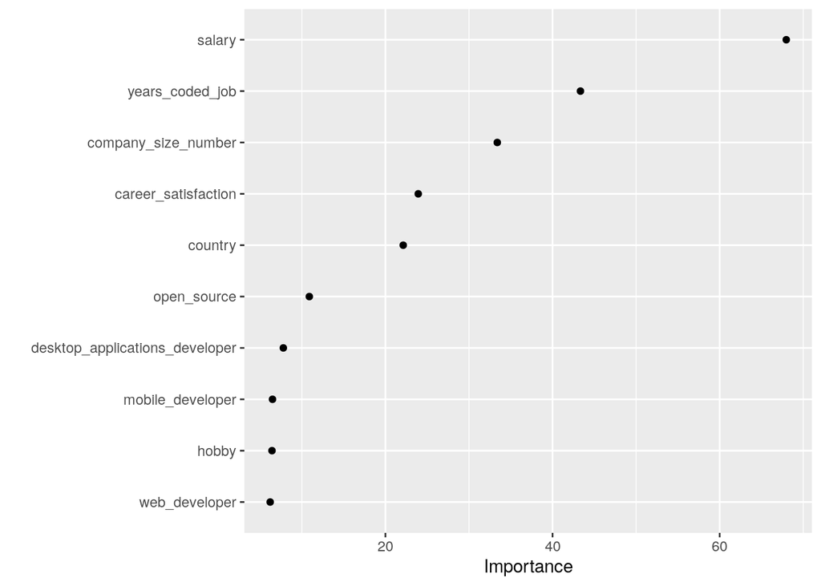

```r
imp_plot <- get_tree_fit(imp_fit)
vip::vip(imp_plot, geom = "point")
```

# Your Turn 7

Make a new model spec called `treebag_imp_spec` to fit a bagged classification tree model. Set the variable `importance` mode to “permutation”. Plot the variable importance- which variable was the most important?

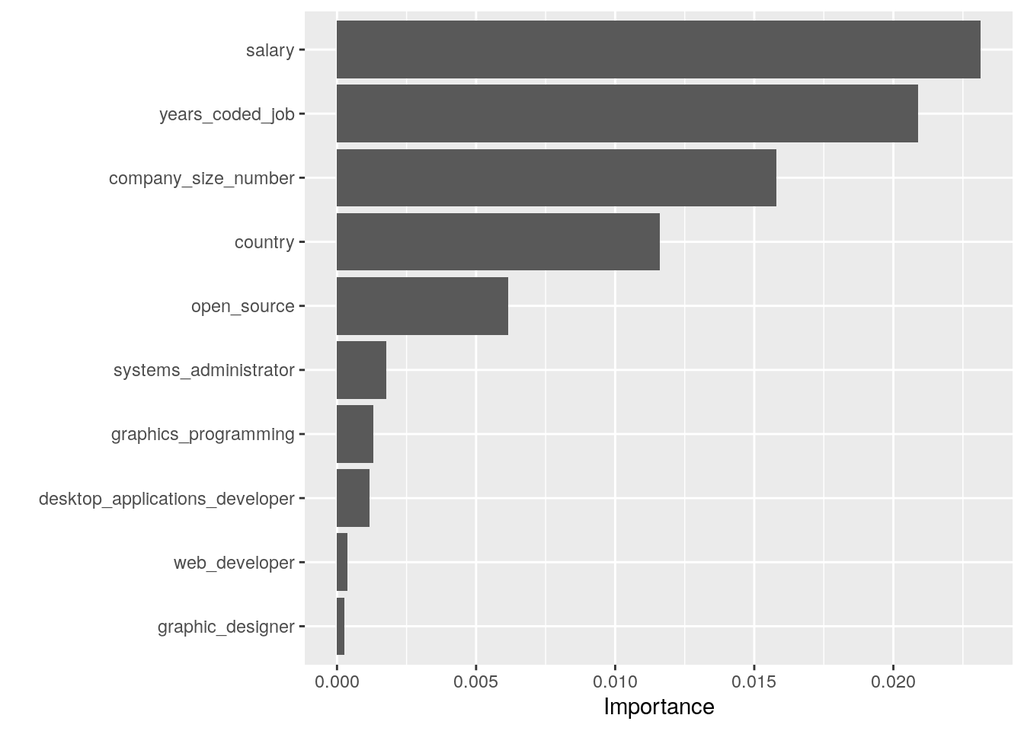

```r
treebag_imp_spec <- rand_forest(mtry = .preds()) %>%
  set_engine("ranger", importance = "permutation") %>%
  set_mode("classification")

set.seed(100)
treebag_imp_fit <- fit_split(remote ~ .,
          model = treebag_imp_spec,
          split = so_split)
treebag_imp_plot <- get_tree_fit(treebag_imp_fit)
vip::vip(treebag_imp_plot, geom = "col")
```